# Multifactorial Design and interactions key

John Shorter

Mar/13/2024

# Load packages

```r
library(emmeans)
library(multcomp)
```

```r
library(multcompView)
library(ggplot2)
library(tidyr)
library(dplyr)
library(readr)
library(readxl)
library(RColorBrewer)
library(viridis)
```

# Exercise

Now you have learned how to analyze multifactorial experiment. You will practice it.

We will use an actual experiment “potato yield” as example. In this experiment, we are looking at the yield of two varieties of potato across different nitrogen input.

Potato from one of the two varieties were randomly assigned one of the 5 nitrogen treatments. At the end of the experiment, potatos were harvested and weighed. (Data from UC Davis Plant Sciences course PLS205, Winter 2017)

```r
Potato_Yield <- read.csv("/work/Data/Rmodule_data/Potato_yield.csv")
head(Potato_Yield)
```

```
##   Nitrogen        Variety    Yield
## 1        0 Russet Burbank 397.6773
## 2       90 Russet Burbank 504.1822
## 3      150 Russet Burbank 501.2186
## 4      210 Russet Burbank 594.7640
## 5      270 Russet Burbank 607.4754
## 6        0  Alpine Russet 296.9766
```

```r
str(Potato_Yield)
```

```
## 'data.frame':    100 obs. of  3 variables:
##  $ Nitrogen: int  0 90 150 210 270 0 90 150 210 270 ...
##  $ Variety : chr  "Russet Burbank" "Russet Burbank" "Russet Burbank" "Russet Burbank" ...
##  $ Yield   : num  398 504 501 595 607 ...
```

## Visualize the data

make the best plot you can to visualize the data.

What to put on x axis? What to color/fill with? Any faceting that you want to use?

WARNING: are there any numerically recorded variables you want to change into factors? (Hint: there is 1 variable that you need to change into factor.)

Make your plot here:

[output not shown]

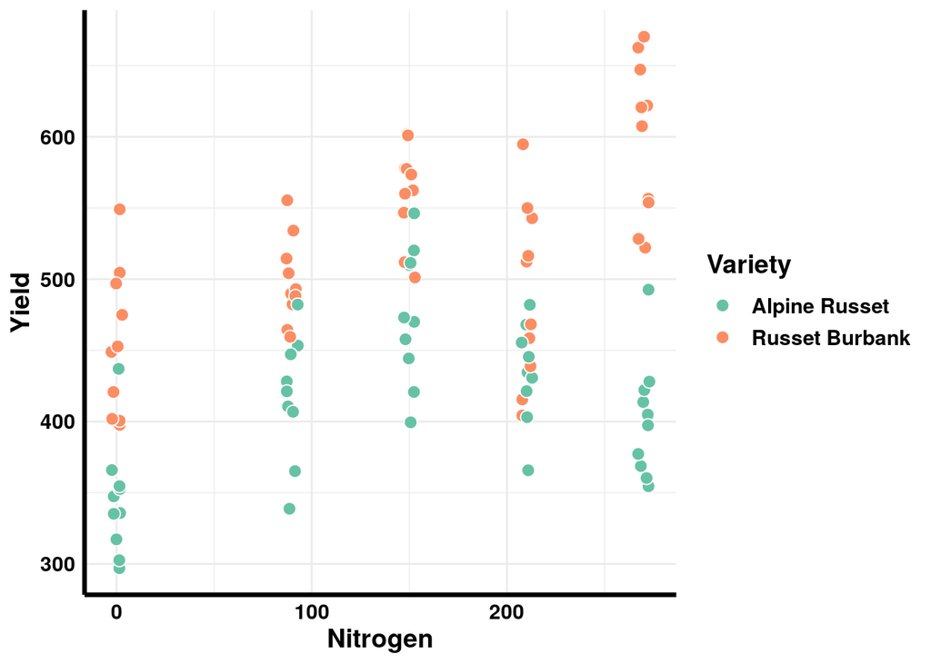

```r
Potato_Yield %>%
  ggplot(aes(x = Nitrogen, y = Yield)) +
  geom_point(aes(fill = Variety), size = 3, color = "white", shape = 21,
             position = position_jitter(3, seed = 666)) +
  scale_fill_brewer(type = "qual", palette = "Set2") +
  labs(y = "Yield") +
  theme_minimal() +
  theme(
    axis.line = element_line(size = 1.2),
    text = element_text(size = 14, color = "black", face = "bold"),
    axis.text = element_text(color = "black")
  )
```

## Setting up the model

Fill out the table:

What are the sources of variation? What factors are they? (treatment? block? observational units? experimental units?) How many levels in each?

| source | factor | levels |
| --- | --- | --- |
| Variety | Treatment | 2 |
| Nitrogen | Treatment | 5 |
| potato | EU, OU | 100 |

(The potato yield table has 100 rows. Because it is a tidy table, I know there is total of 100 potatoes.)

What main effects should you include in the model? Which interactions should you include in the model?

Set up the linear model.

```r
Potato_Yield <- Potato_Yield %>%
  mutate(Nitrogen.F = as.factor(Nitrogen)) #don't forget to change numeric variable to factor for ANOVA

model_potato <- lm(Yield ~ Variety * Nitrogen.F, data = Potato_Yield)
```

## Check assumptions of ANOVA

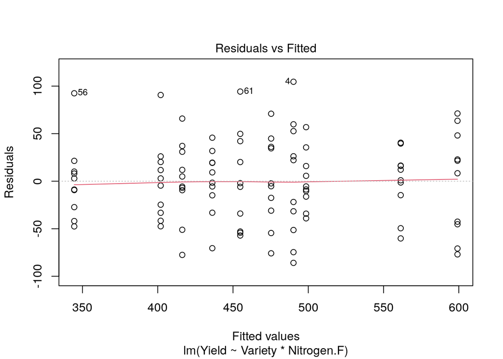

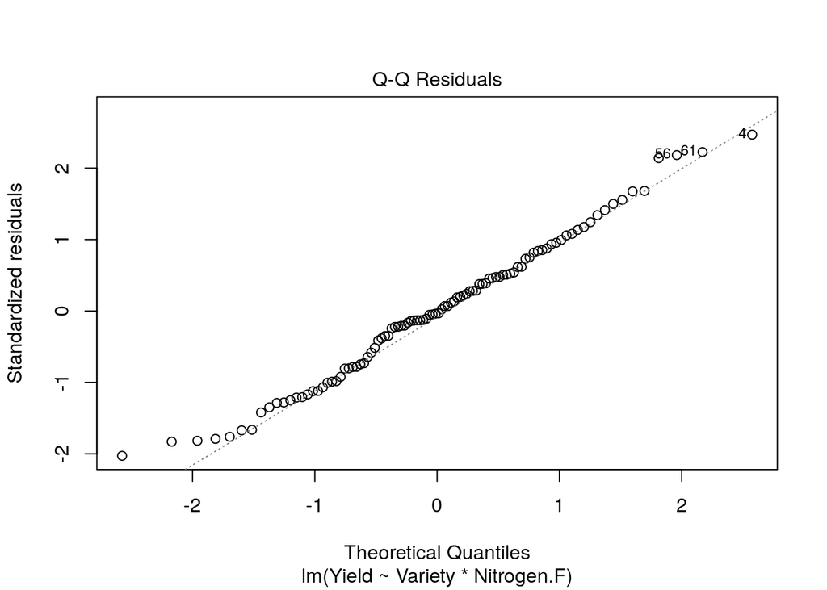

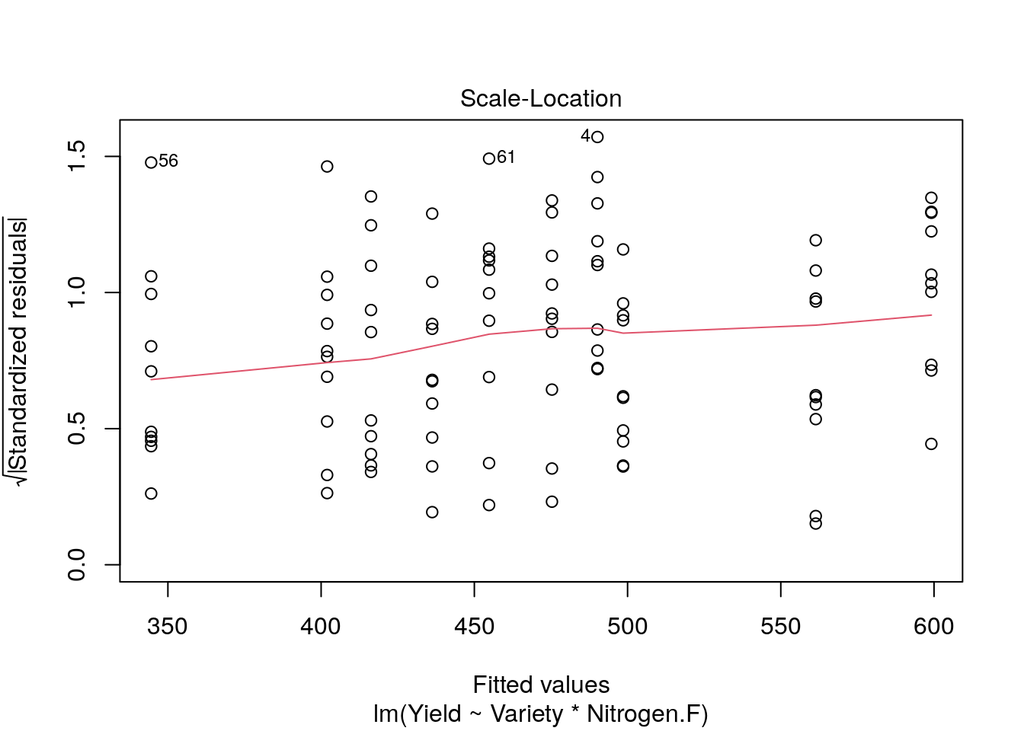

```r
plot(model_potato, which = c(1, 2, 3))
```

Normality? Pretty good. Equal variance? Pretty good.

## Run ANOVA

How would you interpret the ANOVA table?

```r
anova(model_potato)
```

```
## Analysis of Variance Table
##
## Response: Yield
##                    Df Sum Sq Mean Sq  F value    Pr(>F)
## Variety             1 280604  280604 140.7279 < 2.2e-16 ***
## Nitrogen.F          4 167984   41996  21.0617 2.790e-12 ***
## Variety:Nitrogen.F  4  60001   15000   7.5229 2.831e-05 ***
## Residuals          90 179456    1994
## ---
## Signif. codes:  0 '***' 0.001 '**' 0.01 '*' 0.05 '.' 0.1 ' ' 1
```

Variety explains the most variation (F = 140), followed by Nitrogen (as a factor, F= 21), followed by their interaction (F = 7)

## Tukey test

Say we are interested in knowing which variety performs better for each nitrogen input. How should you set up the Tukey test?

```r
estimate_potato_per_nitrogen <- emmeans(model_potato, pairwise ~ Variety | Nitrogen.F)
```

Pull out the cld output and interpret the results.

```r
cld(estimate_potato_per_nitrogen$emmeans, Letters = letters)
```

```
## Nitrogen.F = 0:
##  Variety        emmean   SE df lower.CL upper.CL .group
##  Alpine Russet     345 14.1 90      316      373  a
##  Russet Burbank    455 14.1 90      427      483   b
##
## Nitrogen.F = 90:
##  Variety        emmean   SE df lower.CL upper.CL .group
##  Alpine Russet     416 14.1 90      388      444  a
##  Russet Burbank    499 14.1 90      471      527   b
##
## Nitrogen.F = 150:
##  Variety        emmean   SE df lower.CL upper.CL .group
##  Alpine Russet     475 14.1 90      447      503  a
##  Russet Burbank    561 14.1 90      533      589   b
##
## Nitrogen.F = 210:
##  Variety        emmean   SE df lower.CL upper.CL .group
##  Alpine Russet     436 14.1 90      408      464  a
##  Russet Burbank    490 14.1 90      462      518   b
##
## Nitrogen.F = 270:
##  Variety        emmean   SE df lower.CL upper.CL .group
##  Alpine Russet     402 14.1 90      374      430  a
##  Russet Burbank    599 14.1 90      571      627   b
##
## Confidence level used: 0.95
## significance level used: alpha = 0.05
## NOTE: If two or more means share the same grouping symbol,
##       then we cannot show them to be different.
##       But we also did not show them to be the same.
```

Across all 5 nitrogen treatment, Russet Burbank has higher yield than Alpine Russet.